# Road Collision Severity Analysis — Great Britain 2023

## 5.5 Urban vs. Rural Area (`urban_or_rural_area`)

Rural roads are consistently over-represented in fatal collisions in the UK, despite lower absolute collision volumes, due to higher speed limits, less roadside infrastructure, and longer emergency response times.

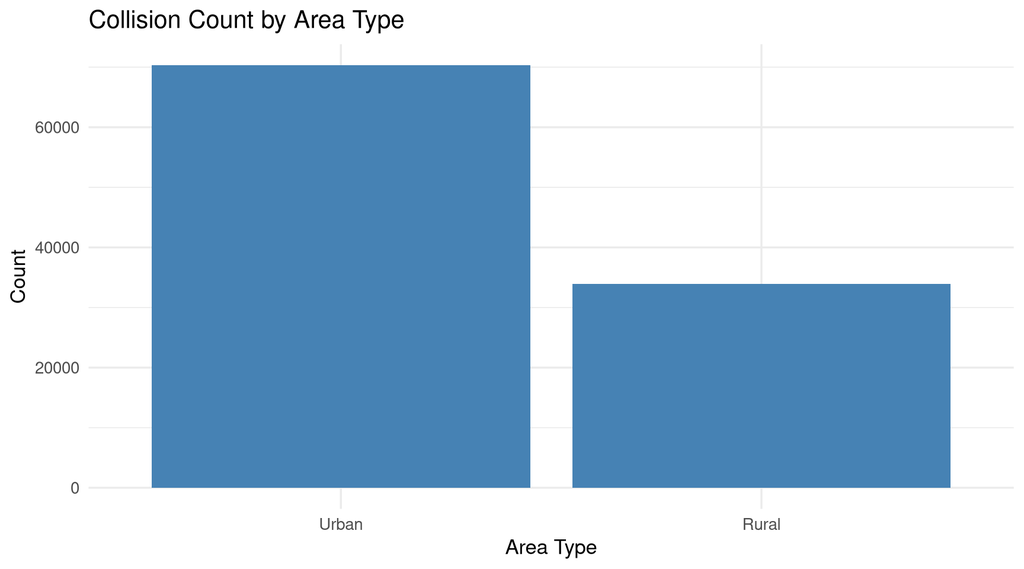

```r
data %>%
  filter(!is.na(urban_or_rural_area), urban_or_rural_area %in% c(1, 2)) %>%
  mutate(area_f = factor(urban_or_rural_area, levels = c(1, 2),
                          labels = c("Urban", "Rural"))) %>%
  ggplot(aes(x = area_f)) +
  geom_bar(fill = "steelblue") +
  labs(title = "Collision Count by Area Type", x = "Area Type", y = "Count") +
  theme_minimal(base_size = 13)
```

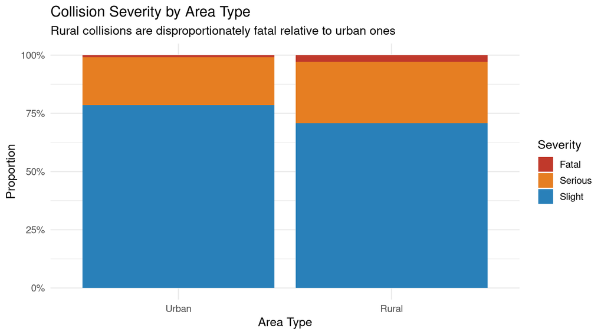

```r
data %>%
  filter(!is.na(urban_or_rural_area), urban_or_rural_area %in% c(1, 2),
         !is.na(collision_severity)) %>%
  mutate(area_f = factor(urban_or_rural_area, levels = c(1, 2),
                          labels = c("Urban", "Rural"))) %>%
  ggplot(aes(x = area_f, fill = collision_severity)) +
  geom_bar(position = "fill") +
  scale_fill_manual(
    values = c("Fatal" = "#c0392b", "Serious" = "#e67e22", "Slight" = "#2980b9"),
    name   = "Severity"
  ) +
  scale_y_continuous(labels = scales::percent_format()) +
  labs(
    title    = "Collision Severity by Area Type",
    subtitle = "Rural collisions are disproportionately fatal relative to urban ones",
    x        = "Area Type",
    y        = "Proportion"
  ) +
  theme_minimal(base_size = 13)
```

The contrast is striking: **rural collisions** have a substantially higher fatal proportion than urban collisions, despite accounting for only 32.6% of total events. This is consistent with the national picture — rural roads are responsible for around 60% of road fatalities in Great Britain.

## 5.6 Number of Casualties (`number_of_casualties`)

```r
desc_stats(data, "number_of_casualties")
```

```
##   N (non-missing) : 104258
##   Mean            : 1.275
##   Median          : 1.000
##   SD              : 0.737
##   Min / Max       : 1.0 / 70.0
```

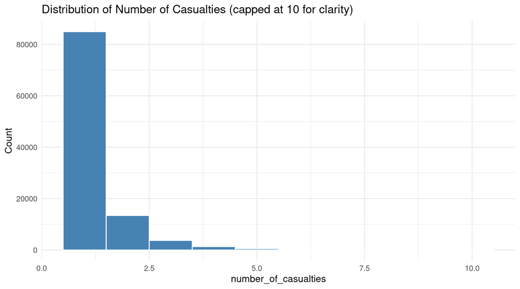

```r
plot_histogram(data %>% filter(number_of_casualties <= 10),
               "number_of_casualties",
               "Distribution of Number of Casualties (capped at 10 for clarity)",
               bins = 10)
```

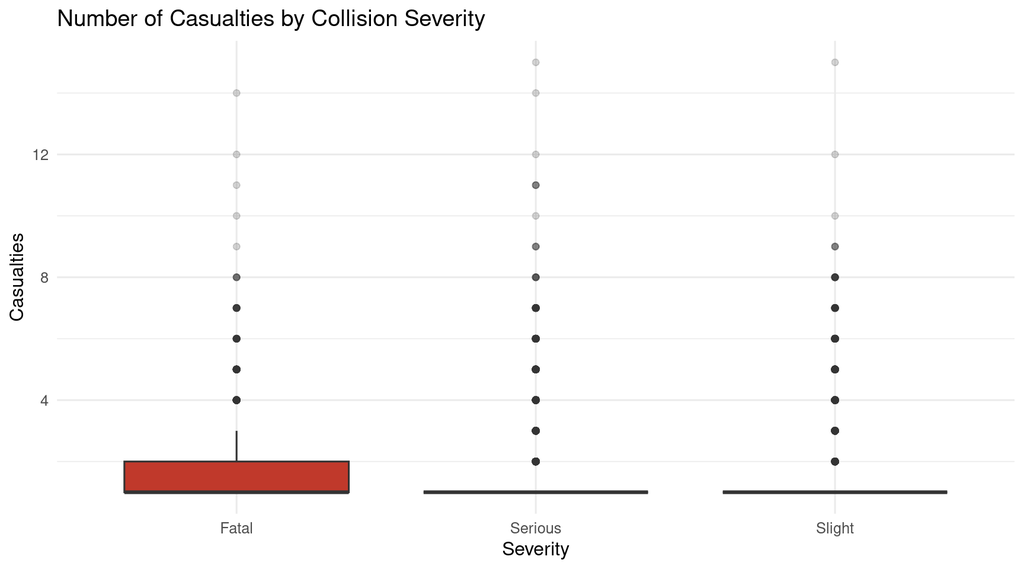

```r
plot_boxplot_severity(
  data %>% filter(number_of_casualties <= 15),
  "number_of_casualties",
  "Number of Casualties by Collision Severity",
  y_label = "Casualties"
)
```

## 5.7 Temporal Patterns: Day of Week

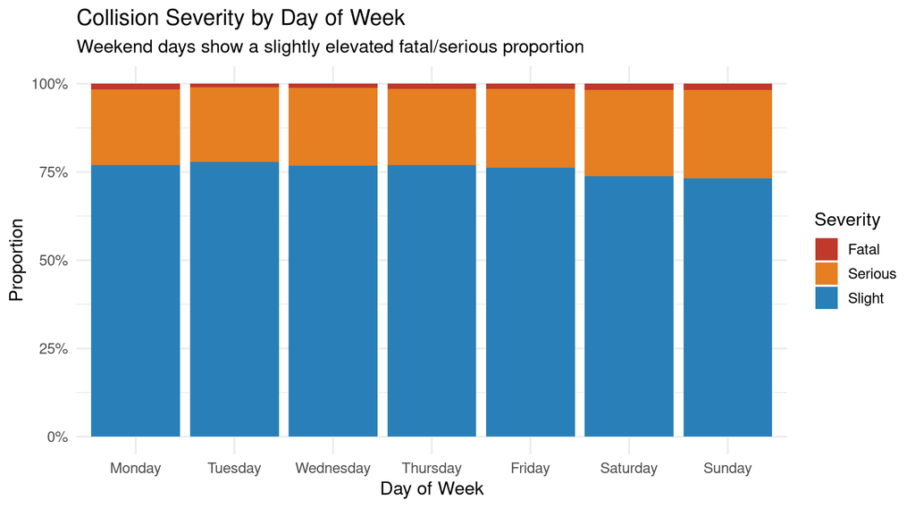

```r
dow_labels <- c("1" = "Sunday", "2" = "Monday", "3" = "Tuesday",
                 "4" = "Wednesday", "5" = "Thursday", "6" = "Friday",
                 "7" = "Saturday")

data %>%
  filter(!is.na(day_of_week)) %>%
  mutate(dow_f = recode(factor(day_of_week), !!!dow_labels),
         dow_f = fct_relevel(dow_f, "Monday","Tuesday","Wednesday",
                              "Thursday","Friday","Saturday","Sunday")) %>%
  ggplot(aes(x = dow_f, fill = collision_severity)) +
  geom_bar(position = "fill") +
  scale_fill_manual(
    values = c("Fatal" = "#c0392b", "Serious" = "#e67e22", "Slight" = "#2980b9"),
    name   = "Severity"
  ) +
  scale_y_continuous(labels = scales::percent_format()) +
  labs(
    title    = "Collision Severity by Day of Week",
    subtitle = "Weekend days show a slightly elevated fatal/serious proportion",
    x        = "Day of Week",
    y        = "Proportion"
  ) +
  theme_minimal(base_size = 13)
```

# 6 EDA Conclusion

The dataset is structurally missing values for several variables (particularly junction-related fields where no junction was present), and requires careful treatment before modelling.

# 7 Data Preprocessing

The preprocessing pipeline addresses four components:

1. **Column selection** — dropping uninformative or structurally problematic columns
2. **Missing value imputation** — for operational variables with < 10% missingness
3. **One-hot encoding** — of all retained categorical variables
4. **Log transformation and standardisation** — of skewed continuous features

## 7.1 Column Selection

```r
# Columns to drop:
#  - Identifiers (no predictive value)
#  - Administrative/geographic codes (too granular or redundant)
#  - Historic legacy columns (superseded by current versions)
#  - Columns with > 40% missing
#  - Target-leaking enhanced severity columns

cols_to_drop <- c(
  "collision_index", "collision_ref_no", "collision_year",
  "location_easting_osgr", "location_northing_osgr",
  "local_authority_district", "local_authority_ons_district",
  "local_authority_highway", "local_authority_highway_current",
  "first_road_number", "second_road_number",
  "junction_detail_historic", "junction_control",
  "pedestrian_crossing_human_control_historic",
  "pedestrian_crossing_physical_facilities_historic",
  "carriageway_hazards_historic",
  "enhanced_severity_collision",
  "collision_injury_based",
  "collision_adjusted_severity_serious",
  "collision_adjusted_severity_slight",
  "lsoa_of_accident_location",
  "trunk_road_flag",
  "date", "time",
  "police_force"
)

data_clean <- data %>% select(-any_of(cols_to_drop))

cat("Retained columns:", ncol(data_clean), "\n")
```

```
## Retained columns: 19
```

```r
cat("Dropped columns :", length(cols_to_drop), "\n")
```

```
## Dropped columns : 25
```

## 7.2 Missing Value Imputation

```r
# Before imputation: record counts
cat("=== Missing values before imputation ===\n")
```

```
## === Missing values before imputation ===
```

```r
data_clean %>%
  summarise(across(everything(), ~ sum(is.na(.)))) %>%
  pivot_longer(everything(), names_to = "variable", values_to = "n_missing") %>%
  filter(n_missing > 0) %>%
  arrange(desc(n_missing)) %>%
  print()
```

```
## # A tibble: 9 × 2
##   variable                   n_missing
##   <chr>                          <int>
## 1 special_conditions_at_site      3116
## 2 carriageway_hazards             3086
## 3 pedestrian_crossing             2768
## 4 junction_detail                 2398
## 5 road_surface_conditions         1064
## 6 second_road_class                 84
## 7 longitude                         12
## 8 latitude                          12
## 9 urban_or_rural_area                8
```

```r
# Strategy:
# - Numeric skewed  → median imputation (robust to outliers)
# - Numeric symmetric → mean imputation
# - All imputed variables have < 10% missing

data_clean <- data_clean %>%
  mutate(
    road_surface_conditions  = ifelse(is.na(road_surface_conditions),
                                      median(road_surface_conditions, na.rm = TRUE),
                                      road_surface_conditions),
    weather_conditions       = ifelse(is.na(weather_conditions),
                                      median(weather_conditions, na.rm = TRUE),
                                      weather_conditions),
    carriageway_hazards      = ifelse(is.na(carriageway_hazards),
                                      median(carriageway_hazards, na.rm = TRUE),
                                      carriageway_hazards),
    special_conditions_at_site = ifelse(is.na(special_conditions_at_site),
                                        median(special_conditions_at_site, na.rm = TRUE),
                                        special_conditions_at_site),
    junction_detail          = ifelse(is.na(junction_detail),
                                      0,  # 0 = no junction; structurally informative
                                      junction_detail),
    pedestrian_crossing      = ifelse(is.na(pedestrian_crossing),
                                      0,
                                      pedestrian_crossing),
    longitude                = ifelse(is.na(longitude),
                                      mean(longitude, na.rm = TRUE),
                                      longitude),
    latitude                 = ifelse(is.na(latitude),
                                      mean(latitude, na.rm = TRUE),
                                      latitude),
    urban_or_rural_area      = ifelse(is.na(urban_or_rural_area),
                                      median(urban_or_rural_area, na.rm = TRUE),
                                      urban_or_rural_area)
  )

cat("\n=== Missing values after imputation ===\n")
```

```
##
## === Missing values after imputation ===
```

```r
data_clean %>%
  summarise(across(everything(), ~ sum(is.na(.)))) %>%
  pivot_longer(everything(), names_to = "variable", values_to = "n_missing") %>%
  filter(n_missing > 0) %>%
  arrange(desc(n_missing)) %>%
  print()
```

```
## # A tibble: 1 × 2
##   variable          n_missing
##   <chr>                 <int>
## 1 second_road_class        84
```

**Imputation decisions:**

- Variables representing absence of a feature (`junction_detail`, `pedestrian_crossing`) are imputed with `0`, which is the DfT code for “none” — this is semantically correct rather than arbitrary
- Distributional variables (`road_surface_conditions`, `weather_conditions`) are imputed with the median, which is robust to the ordinal encoding and skewed distribution
- Geographic coordinates are imputed with their mean, as the 12 affected records represent a negligible fraction

## 7.3 One-Hot Encoding

```r
# Categorical variables to encode (integer-coded, non-ordinal)
cat_vars <- c(
  "road_type",
  "light_conditions",
  "weather_conditions",
  "road_surface_conditions",
  "urban_or_rural_area",
  "day_of_week",
  "junction_detail",
  "pedestrian_crossing",
  "special_conditions_at_site",
  "carriageway_hazards",
  "first_road_class",
  "second_road_class"
)

data_encoded <- dummy_cols(
  data_clean,
  select_columns      = cat_vars,
  remove_selected_columns = TRUE,
  remove_first_dummy  = TRUE   # drop one level to avoid multicollinearity
)

cat("Dimensions after encoding:\n")
```

```
## Dimensions after encoding:
```

```r
cat("  Rows   :", nrow(data_encoded), "\n")
```

```
##   Rows   : 104258
```

```r
cat("  Columns:", ncol(data_encoded), "\n")
```

```
##   Columns: 82
```

One-hot encoding expands each categorical variable into binary indicator columns, one per level (minus one, to avoid perfect multicollinearity). The `remove_first_dummy = TRUE` argument drops the reference category in each group.

## 7.4 Log Transformation and Standardisation

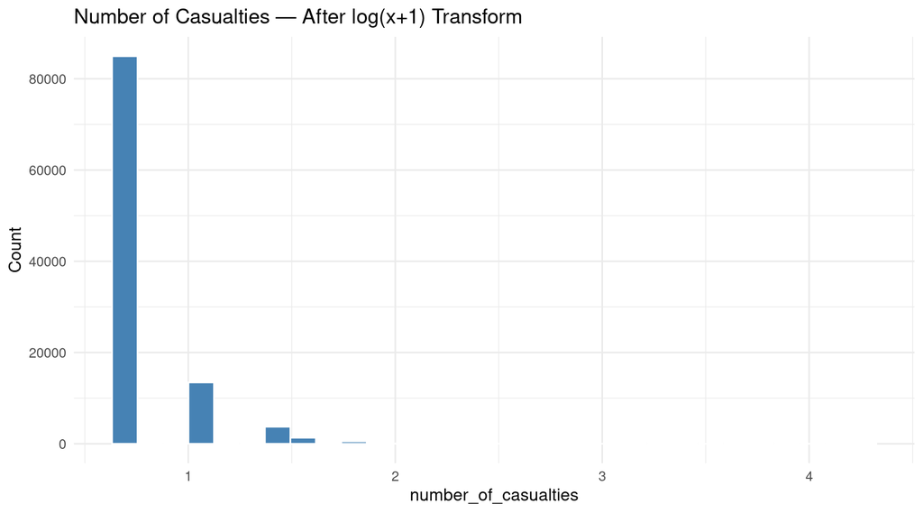

```r
# Variables requiring log transformation (strong right skew confirmed in EDA)
skewed_vars <- c("number_of_casualties", "number_of_vehicles")

# Apply log(x + 1) to avoid issues with zeros
for (v in skewed_vars) {
  data_encoded[[v]] <- log1p(data_encoded[[v]])
}

# Visual check
plot_histogram(data_encoded, "number_of_casualties",
               "Number of Casualties — After log(x+1) Transform")
```

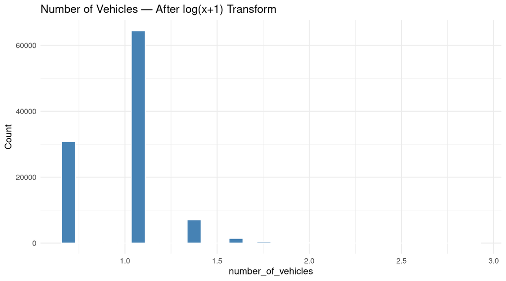

```r
plot_histogram(data_encoded, "number_of_vehicles",
               "Number of Vehicles — After log(x+1) Transform")
```

```r
# Standardise all continuous features (mean = 0, sd = 1)
vars_to_scale <- c("number_of_casualties", "number_of_vehicles",
                   "speed_limit", "longitude", "latitude")

for (v in vars_to_scale) {
  data_encoded[[v]] <- as.numeric(scale(data_encoded[[v]]))
}

# Verify
summary(data_encoded[, vars_to_scale])
```

```
##  number_of_casualties number_of_vehicles  speed_limit        longitude
##  Min.   :-0.4349      Min.   :-1.3691    Min.   :-1.1062   Min.   :-4.61299
##  1st Qu.:-0.4349      1st Qu.:-1.3691    1st Qu.:-0.4093   1st Qu.:-0.65812
##  Median :-0.4349      Median : 0.3841    Median :-0.4093   Median : 0.09074
##  Mean   : 0.0000      Mean   : 0.0000    Mean   : 0.0000   Mean   : 0.00000
##  3rd Qu.:-0.4349      3rd Qu.: 0.3841    3rd Qu.: 0.2876   3rd Qu.: 0.79339
##  Max.   :15.4131      Max.   : 8.1316    Max.   : 2.3783   Max.   : 2.19436
##     latitude
##  Min.   :-1.8568
##  1st Qu.:-0.6864
##  Median :-0.4146
##  Mean   : 0.0000
##  3rd Qu.: 0.7399
##  Max.   : 5.9703
```

Log transformation reduces the right skew of `number_of_casualties` and `number_of_vehicles`, preventing extreme values from dominating linear model coefficients. Subsequent standardisation places all continuous features on a common scale (mean ≈ 0, SD ≈ 1), which is essential for distance-based algorithms and regularised regression models.

## 7.5 Final Dataset

```r
cat("=== Final preprocessed dataset ===\n")
```

```
## === Final preprocessed dataset ===
```

```r
cat("  Rows               :", nrow(data_encoded), "\n")
```

```
##   Rows               : 104258
```

```r
cat("  Columns (features) :", ncol(data_encoded) - 1, "\n")
```

```
##   Columns (features) : 81
```

```r
cat("  Target variable    : collision_severity\n\n")
```

```
##   Target variable    : collision_severity
```

```r
cat("Target class distribution:\n")
```

```
## Target class distribution:
```

```r
round(prop.table(table(data_encoded$collision_severity)) * 100, 2)
```

```
##
##   Fatal Serious  Slight
##    1.46   22.48   76.06
```

```r
# Suppression des lignes avec NA résiduels
data_encoded <- data_encoded %>% drop_na()
cat("Lignes après suppression des NA résiduels :", nrow(data_encoded), "\n")
```

```
## Lignes après suppression des NA résiduels : 104174
```

# 8 Preprocessing Conclusion

The resulting dataset `data_encoded` is ready for model training. Given the severe class imbalance (76% Slight / 22.5% Serious / 1.5% Fatal), any downstream modelling phase should employ appropriate strategies such as SMOTE oversampling, class-weighted objectives, or threshold calibration — particularly to improve sensitivity for the critical Fatal class.

# 9 Predictive Modelling

The objective of this section is to build and evaluate classification models capable of predicting `collision_severity` from the preprocessed features. Given the three-level ordinal target and the marked class imbalance identified during EDA, particular care is taken to ensure that the Fatal class — despite its low prevalence — is adequately captured by each model.

## 9.1 Modelling Setup

### 9.1.1 Train / Test Split

```r
set.seed(42)

n      <- nrow(data_encoded)
idx    <- sample(seq_len(n), size = floor(0.8 * n))
train  <- data_encoded[ idx, ]
test   <- data_encoded[-idx, ]

cat("Training set :", nrow(train), "observations\n")
```

```
## Training set : 83339 observations
```

```r
cat("Test set     :", nrow(test),  "observations\n\n")
```

```
## Test set     : 20835 observations
```

```r
cat("Class distribution — Training set:\n")
```

```
## Class distribution — Training set:
```

```r
round(prop.table(table(train$collision_severity)) * 100, 2)
```

```
##
##   Fatal Serious  Slight
##    1.46   22.41   76.13
```

```r
cat("\nClass distribution — Test set:\n")
```

```
##
## Class distribution — Test set:
```

```r
round(prop.table(table(test$collision_severity)) * 100, 2)
```

```
##
##   Fatal Serious  Slight
##    1.45   22.75   75.80
```

The 80/20 split is performed with a fixed random seed to ensure reproducibility. The class proportions are preserved by construction given the large sample size.

```r
library(ROSE)

# ROSE ne supporte que 2 classes — oversampling manuel par rééchantillonnage
set.seed(42)

# Taille cible par classe = taille de la classe majoritaire
target_n <- max(table(train$collision_severity))

train_balanced <- train %>%
  group_by(collision_severity) %>%
  slice_sample(n = target_n, replace = TRUE) %>%
  ungroup() %>%
  slice_sample(prop = 1)  # mélanger les lignes

cat("Class distribution — After oversampling:\n")
```

```
## Class distribution — After oversampling:
```

```r
round(prop.table(table(train_balanced$collision_severity)) * 100, 2)
```

```
##
##   Fatal Serious  Slight
##   33.33   33.33   33.33
```

> **Important:** Oversampling is applied exclusively to the training set. The test set retains the original class distribution to produce realistic, unbiased evaluation metrics.

### 9.1.3 Evaluation Helper

```r
# Compute a full classification report: per-class precision, recall, F1,
# plus macro-averaged F1 — the primary metric given class imbalance.

classification_report <- function(conf_mat, model_name = "") {
  classes <- rownames(conf_mat)
  n_class <- length(classes)

  metrics <- data.frame(
    Class     = classes,
    Precision = numeric(n_class),
    Recall    = numeric(n_class),
    F1        = numeric(n_class),
    Support   = numeric(n_class)
  )

  for (i in seq_along(classes)) {
    TP <- conf_mat[i, i]
    FP <- sum(conf_mat[, i]) - TP
    FN <- sum(conf_mat[i, ]) - TP

    precision <- ifelse((TP + FP) == 0, 0, TP / (TP + FP))
    recall    <- ifelse((TP + FN) == 0, 0, TP / (TP + FN))
    f1        <- ifelse((precision + recall) == 0, 0,
                        2 * precision * recall / (precision + recall))

    metrics$Precision[i] <- round(precision, 3)
    metrics$Recall[i]    <- round(recall,    3)
    metrics$F1[i]        <- round(f1,        3)
    metrics$Support[i]   <- sum(conf_mat[i, ])
  }

  macro_f1 <- round(mean(metrics$F1), 3)
  accuracy <- round(sum(diag(conf_mat)) / sum(conf_mat), 3)

  if (nchar(model_name) > 0) cat("===", model_name, "===\n")
  print(metrics, row.names = FALSE)
  cat(sprintf("\n  Accuracy  : %.3f\n", accuracy))
  cat(sprintf("  Macro F1  : %.3f\n\n", macro_f1))

  invisible(list(metrics = metrics, accuracy = accuracy, macro_f1 = macro_f1))
}

# Confusion matrix plot
plot_confusion_matrix <- function(conf_mat, title) {
  cm_df <- as.data.frame(as.table(conf_mat))
  colnames(cm_df) <- c("Actual", "Predicted", "Count")

  ggplot(cm_df, aes(x = Predicted, y = Actual, fill = Count)) +
    geom_tile(colour = "white") +
    geom_text(aes(label = Count), size = 5, fontface = "bold") +
    scale_fill_gradient(low = "#d6eaf8", high = "#1a5276") +
    labs(title = title, x = "Predicted", y = "Actual") +
    theme_minimal(base_size = 13) +
    theme(legend.position = "none")
}
```

## 9.2 Model 1 — Multinomial Logistic Regression

Logistic regression is the natural baseline for a multi-class classification problem. Its coefficients are directly interpretable as log-odds, making it valuable for understanding the direction and magnitude of each predictor’s effect.

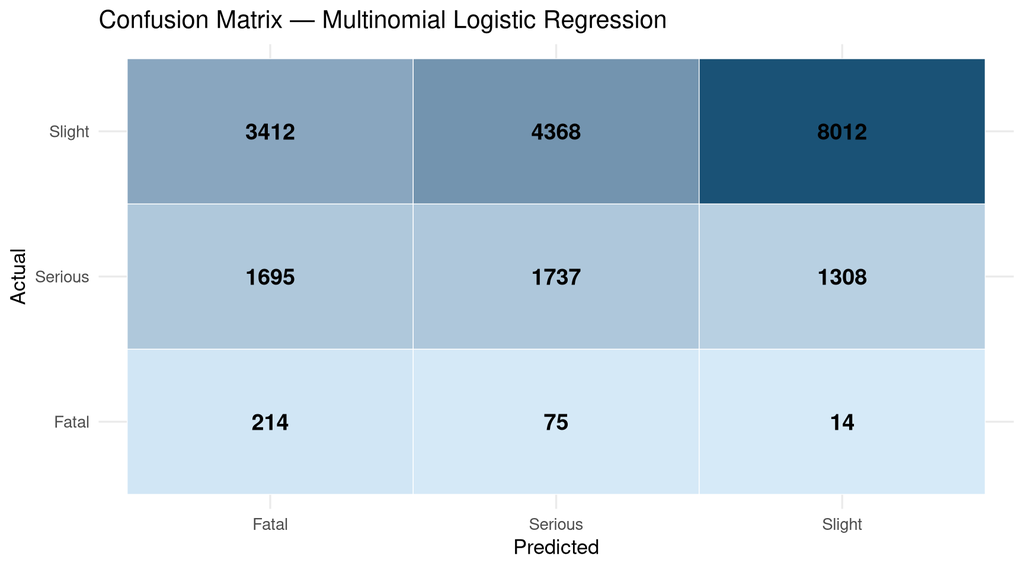

```r
library(nnet)

# Train on the ROSE-balanced training set
logit_model <- multinom(
  collision_severity ~ .,
  data    = train_balanced,
  maxit   = 200,
  trace   = FALSE
)

# Predict on the original (unbalanced) test set
logit_pred <- predict(logit_model, newdata = test)

# Confusion matrix
logit_cm <- table(Actual = test$collision_severity,
                  Predicted = logit_pred)

plot_confusion_matrix(logit_cm, "Confusion Matrix — Multinomial Logistic Regression")
```

```r
logit_results <- classification_report(logit_cm, "Multinomial Logistic Regression")
```

```
## === Multinomial Logistic Regression ===
##    Class Precision Recall    F1 Support
##    Fatal     0.040  0.706 0.076     303
##  Serious     0.281  0.366 0.318    4740
##   Slight     0.858  0.507 0.638   15792
##
##   Accuracy  : 0.478
##   Macro F1  : 0.344
```

Logistic regression provides a transparent, interpretable baseline. Its performance on the Fatal class will be limited by the linear decision boundary, but the coefficient estimates offer valuable insight into the direction of predictor effects.

## 9.3 Model 2 — Decision Tree

A decision tree partitions the feature space through a sequence of binary splits. It is fully interpretable (the decision rules can be read directly), handles non-linear relationships, and naturally accommodates categorical variables.

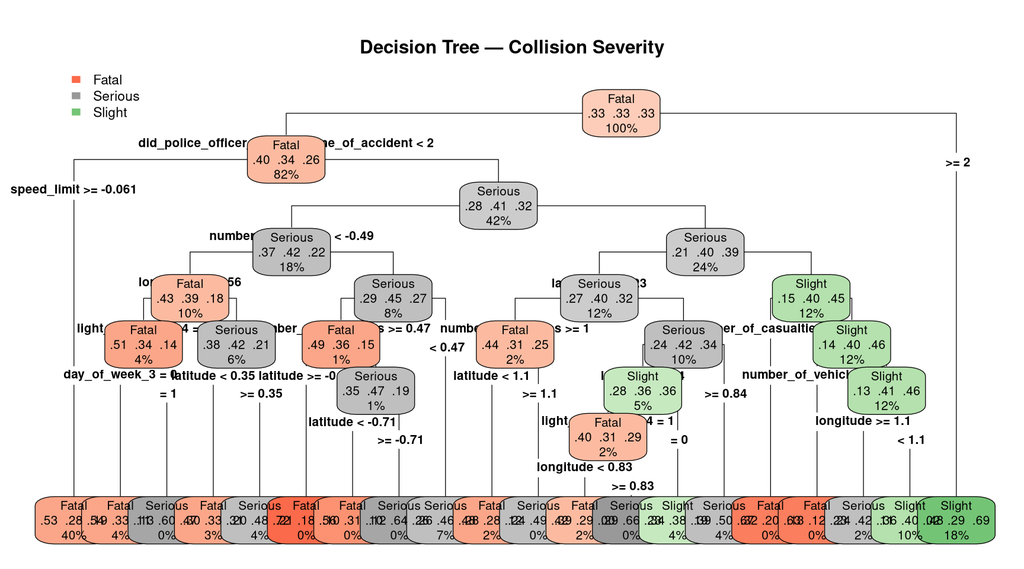

```r
library(rpart)
library(rpart.plot)

# Train the tree with balanced class weights
dt_model <- rpart(
  collision_severity ~ .,
  data    = train_balanced,
  method  = "class",
  control = rpart.control(
    minsplit = 20,
    cp       = 0.001,
    maxdepth = 8
  )
)

# Visualise the tree (top levels only for readability)
rpart.plot(
  dt_model,
  type    = 4,
  extra   = 104,
  fallen.leaves = TRUE,
  main    = "Decision Tree — Collision Severity",
  cex     = 0.65
)
```

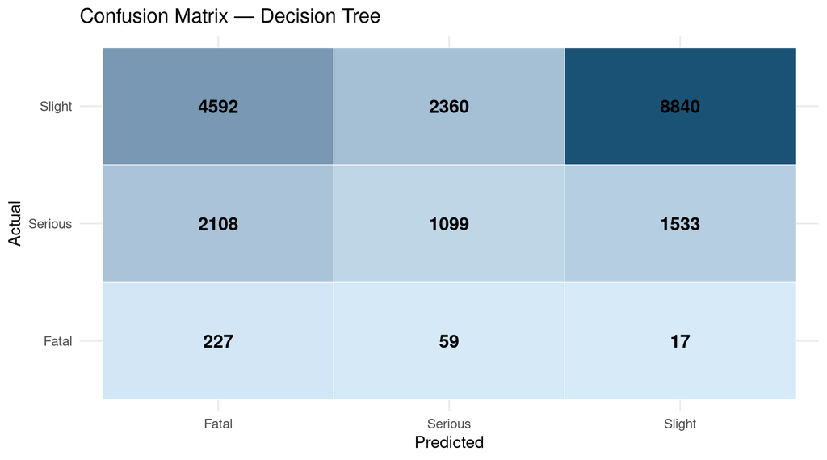

```r
# Predict
dt_pred <- predict(dt_model, newdata = test, type = "class")

# Confusion matrix
dt_cm <- table(Actual = test$collision_severity, Predicted = dt_pred)
plot_confusion_matrix(dt_cm, "Confusion Matrix — Decision Tree")
```

```r
dt_results <- classification_report(dt_cm, "Decision Tree")
```

```
## === Decision Tree ===
##    Class Precision Recall    F1 Support
##    Fatal     0.033  0.749 0.063     303
##  Serious     0.312  0.232 0.266    4740
##   Slight     0.851  0.560 0.675   15792
##
##   Accuracy  : 0.488
##   Macro F1  : 0.335
```

## 9.4 Model 3 — Random Forest

Random Forest is an ensemble of decision trees trained on bootstrap samples of the data, with randomised feature selection at each split. This variance-reduction mechanism typically yields substantially better generalisation than a single tree, while maintaining the ability to rank variable importance.

```r
library(randomForest)

# Subsample for computational feasibility (Random Forest is O(n * p * trees))
set.seed(42)
train_rf <- train_balanced %>%
  group_by(collision_severity) %>%
  slice_sample(n = 3000) %>%
  ungroup()

rf_model <- randomForest(
  collision_severity ~ .,
  data       = train_rf,
  ntree      = 300,
  mtry       = floor(sqrt(ncol(train_rf) - 1)),
  importance = TRUE,
  seed       = 42
)

print(rf_model)
```

```
##
## Call:
##  randomForest(formula = collision_severity ~ ., data = train_rf,      ntree = 300, mtry = floor(sqrt(ncol(train_rf) - 1)), importance = TRUE,      seed = 42)
##                Type of random forest: classification
##                      Number of trees: 300
## No. of variables tried at each split: 9
##
##         OOB estimate of  error rate: 34.4%
## Confusion matrix:
##         Fatal Serious Slight class.error
## Fatal    2845     114     41  0.05166667
## Serious   703    1453    844  0.51566667
## Slight    478     916   1606  0.46466667
```

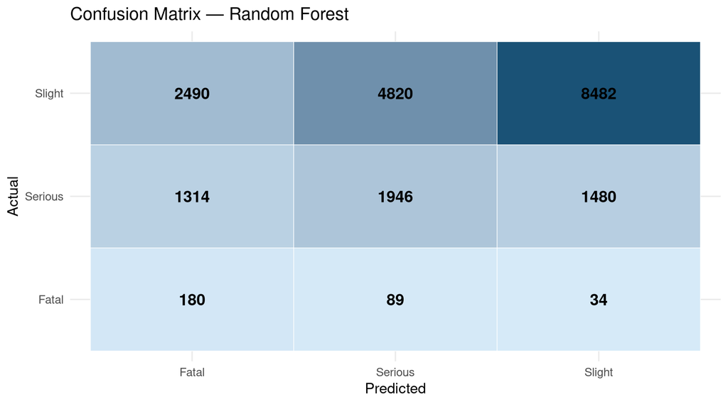

```r
# Predict on full test set
rf_pred <- predict(rf_model, newdata = test)

# Confusion matrix
rf_cm <- table(Actual = test$collision_severity, Predicted = rf_pred)
plot_confusion_matrix(rf_cm, "Confusion Matrix — Random Forest")
```

```r
rf_results <- classification_report(rf_cm, "Random Forest")
```

```
## === Random Forest ===
##    Class Precision Recall    F1 Support
##    Fatal     0.045  0.594 0.084     303
##  Serious     0.284  0.411 0.336    4740
##   Slight     0.849  0.537 0.658   15792
##
##   Accuracy  : 0.509
##   Macro F1  : 0.359
```

### 9.4.1 Variable Importance

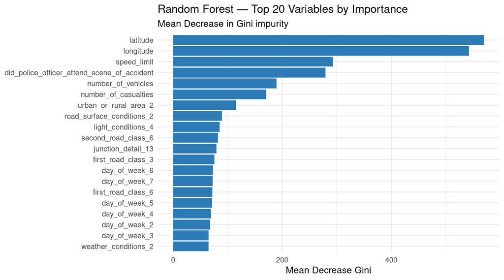

```r
importance_df <- as.data.frame(importance(rf_model))
importance_df$Variable <- rownames(importance_df)

# Use Mean Decrease in Gini (MeanDecreaseGini) for ranking
importance_df %>%
  arrange(desc(MeanDecreaseGini)) %>%
  head(20) %>%
  ggplot(aes(x = reorder(Variable, MeanDecreaseGini), y = MeanDecreaseGini)) +
  geom_col(fill = "#2c7bb6") +
  coord_flip() +
  labs(
    title    = "Random Forest — Top 20 Variables by Importance",
    subtitle = "Mean Decrease in Gini impurity",
    x        = NULL,
    y        = "Mean Decrease Gini"
  ) +
  theme_minimal(base_size = 12)
```

## 9.5 Model Comparison

```r
# Assemble summary table
model_summary <- data.frame(
  Model    = c("Multinomial Logistic Regression", "Decision Tree", "Random Forest"),
  Accuracy = c(logit_results$accuracy, dt_results$accuracy, rf_results$accuracy),
  MacroF1  = c(logit_results$macro_f1, dt_results$macro_f1, rf_results$macro_f1),
  Fatal_F1 = c(
    logit_results$metrics$F1[logit_results$metrics$Class == "Fatal"],
    dt_results$metrics$F1[dt_results$metrics$Class == "Fatal"],
    rf_results$metrics$F1[rf_results$metrics$Class == "Fatal"]
  )
)

model_summary
```

```
##                             Model Accuracy MacroF1 Fatal_F1
## 1 Multinomial Logistic Regression    0.478   0.344    0.076
## 2                   Decision Tree    0.488   0.335    0.063
## 3                   Random Forest    0.509   0.359    0.084
```

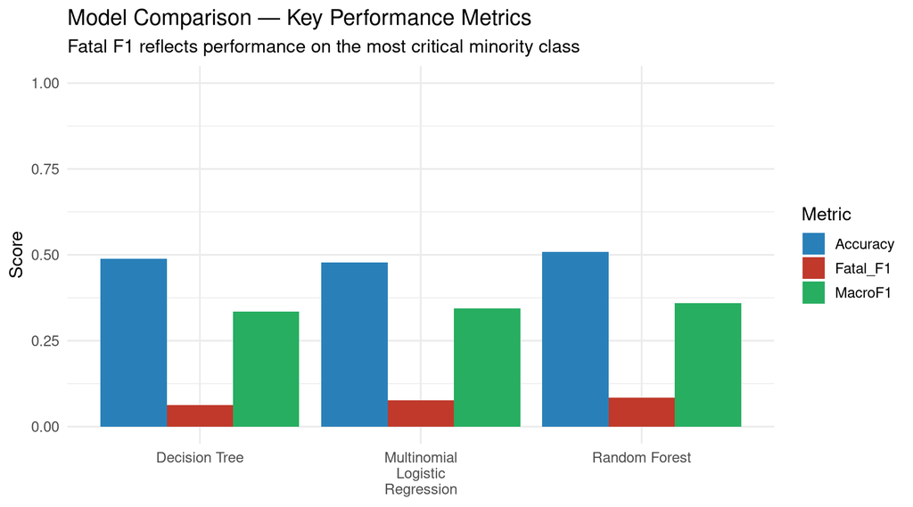

```r
# Visual comparison
model_summary %>%
  pivot_longer(cols = c(Accuracy, MacroF1, Fatal_F1),
               names_to = "Metric", values_to = "Value") %>%
  ggplot(aes(x = Model, y = Value, fill = Metric)) +
  geom_col(position = "dodge") +
  scale_fill_manual(values = c("Accuracy" = "#2980b9",
                                "MacroF1"  = "#27ae60",
                                "Fatal_F1" = "#c0392b")) +
  scale_x_discrete(labels = function(x) str_wrap(x, width = 15)) +
  labs(
    title    = "Model Comparison — Key Performance Metrics",
    subtitle = "Fatal F1 reflects performance on the most critical minority class",
    x        = NULL,
    y        = "Score",
    fill     = "Metric"
  ) +
  theme_minimal(base_size = 13) +
  ylim(0, 1)
```

# 10 Modelling Conclusion

**Key takeaway:** Across all models, the Fatal class remains the hardest to predict due to its low prevalence and the inherent difficulty of distinguishing it from Serious collisions on tabular features alone. Future work should explore gradient boosting (XGBoost / LightGBM) and more aggressive resampling strategies to further improve minority-class sensitivity.